# PROJECT: Exploratory Data Ananlysis (EDA): Diabetes Analysis

## Context & Objective

- Diabetes is one of the most frequent diseases worldwide, and the number of diabetic patients has been growing over the years. The leading cause of Diabetes remains unknown, yet scientists believe that both genetic factors and environmental lifestyle play a significant role in Diabetes.
- A few years ago, researchers studied a tribe in America called the Pima Indians (Pima tribe). In this tribe, the study showed that the ladies are prone to Diabetes very early.
- This exercise aims at analyzing different aspects of Diabetes in the Pima Indians tribe by doing Exploratory Data Analysis.

## Data

The dataset is [HERE](https://drive.google.com/drive/folders/1ZJMtn0b5gm7CAanru4Xp3Ob_46WPmd2X?usp=sharing), and has the following information:

- **Pregnancies:** Number of times pregnant
- **Glucose:** Plasma glucose concentration over 2 hours in an oral glucose tolerance test
- **BloodPressure:** Diastolic blood pressure (mm Hg)
- **SkinThickness:** Triceps skin fold thickness (mm)
- **Insulin:** 2-Hour serum insulin (mu U/ml)
- **BMI:** Body mass index (weight in kg/(height in m)^2)
- **DiabetesPedigreeFunction:** A function which scores likelihood of diabetes based on family history.
- **Age:** Age in years
- **Outcome:** Class variable (0: person is not diabetic or 1: person is diabetic)

## Importing the necessary libraries

```python
# for data manipulation
import pandas as pd
import numpy as np

# for plotting
import seaborn as sns
import matplotlib.pyplot as plt
%matplotlib inline
```

**Comments:**

- Pandas is good for data cleaning and analysis, especially tabular and heterogeneous datasets. The numpy library is good for manipulating numbers, scientific computing.
- Both Matplotlib.pyplot and seaborn are designed for data visualization. Matplotlib.pyplot, a subpackage of matplotlib, is for plotting and seaborn is for advanced fancy plotting.

## Reading the dataset

```python
pima = pd.read_csv("diabetes.csv")
```

## Showing the last 10 records of the dataset

```python
pima.tail(10)
```

|  | Pregnancies | Glucose | BloodPressure | SkinThickness | Insulin | BMI | DiabetesPedigreeFunction | Age | Outcome |
| --- | --- | --- | --- | --- | --- | --- | --- | --- | --- |
| 758 | 1 | 106 | 76 | 0 | 0 | 37.5 | 0.197 | 26 | 0 |
| 759 | 6 | 190 | 92 | 0 | 0 | 35.5 | 0.278 | 66 | 1 |
| 760 | 2 | 88 | 58 | 26 | 16 | 28.4 | 0.766 | 22 | 0 |
| 761 | 9 | 170 | 74 | 31 | 0 | 44.0 | 0.403 | 43 | 1 |
| 762 | 9 | 89 | 62 | 0 | 0 | 22.5 | 0.142 | 33 | 0 |
| 763 | 10 | 101 | 76 | 48 | 180 | 32.9 | 0.171 | 63 | 0 |
| 764 | 2 | 122 | 70 | 27 | 0 | 36.8 | 0.340 | 27 | 0 |
| 765 | 5 | 121 | 72 | 23 | 112 | 26.2 | 0.245 | 30 | 0 |
| 766 | 1 | 126 | 60 | 0 | 0 | 30.1 | 0.349 | 47 | 1 |
| 767 | 1 | 93 | 70 | 31 | 0 | 30.4 | 0.315 | 23 | 0 |

## Showing the columns in the data

```python
pima.columns
```

```
Index(['Pregnancies', 'Glucose', 'BloodPressure', 'SkinThickness', 'Insulin',
       'BMI', 'DiabetesPedigreeFunction', 'Age', 'Outcome'],
      dtype='object')
```

**Comments:**

- There are 9 columns: 'Pregnancies', 'Glucose', 'BloodPressure', 'SkinThickness', 'Insulin', 'BMI', 'DiabetesPedigreeFunction', 'Age', and 'Outcome'

## Showing the first 10 records of the dataset

```python
pima.head(10)
```

|  | Pregnancies | Glucose | BloodPressure | SkinThickness | Insulin | BMI | DiabetesPedigreeFunction | Age | Outcome |
| --- | --- | --- | --- | --- | --- | --- | --- | --- | --- |
| 0 | 6 | 148 | 72 | 35 | 0 | 33.6 | 0.627 | 50 | 1 |
| 1 | 1 | 85 | 66 | 29 | 0 | 26.6 | 0.351 | 31 | 0 |
| 2 | 8 | 183 | 64 | 0 | 0 | 23.3 | 0.672 | 32 | 1 |
| 3 | 1 | 89 | 66 | 23 | 94 | 28.1 | 0.167 | 21 | 0 |
| 4 | 0 | 137 | 40 | 35 | 168 | 43.1 | 2.288 | 33 | 1 |
| 5 | 5 | 116 | 74 | 0 | 0 | 25.6 | 0.201 | 30 | 0 |
| 6 | 3 | 78 | 50 | 32 | 88 | 31.0 | 0.248 | 26 | 1 |
| 7 | 10 | 115 | 0 | 0 | 0 | 35.3 | 0.134 | 29 | 0 |
| 8 | 2 | 197 | 70 | 45 | 543 | 30.5 | 0.158 | 53 | 1 |
| 9 | 8 | 125 | 96 | 0 | 0 | 0.0 | 0.232 | 54 | 1 |

## Displaying the dimension of the dataframe

```python
pima.shape
```

```
(768, 9)
```

**Comments:**

- The dimension gives the number of rows and the number of the columns in the data in the for of a tuple.

## Size of the dataframe

```python
pima.size
```

```
6912
```

**Comments:**

- The size of the pima data is 6912, which is the product of the number of rows by the number of columns.

## Data types of all the variables in the data set

```python
pima.dtypes
```

```
Pregnancies                   int64
Glucose                       int64
BloodPressure                 int64
SkinThickness                 int64
Insulin                       int64
BMI                         float64
DiabetesPedigreeFunction    float64
Age                           int64
Outcome                       int64
dtype: object
```

**Comments:**

## Missing values

```python
pima.isnull().values.any()
```

```
False
```

**Comments:**

- There is no missing value in the pima dataset

## Summary statistics

```python
pima.describe()
```

|  | Pregnancies | Glucose | BloodPressure | SkinThickness | Insulin | BMI | DiabetesPedigreeFunction | Age | Outcome |
| --- | --- | --- | --- | --- | --- | --- | --- | --- | --- |
| count | 768.000000 | 768.000000 | 768.000000 | 768.000000 | 768.000000 | 768.000000 | 768.000000 | 768.000000 | 768.000000 |
| mean | 3.845052 | 120.894531 | 69.105469 | 20.536458 | 79.799479 | 31.992578 | 0.471876 | 33.240885 | 0.348958 |
| std | 3.369578 | 31.972618 | 19.355807 | 15.952218 | 115.244002 | 7.884160 | 0.331329 | 11.760232 | 0.476951 |
| min | 0.000000 | 0.000000 | 0.000000 | 0.000000 | 0.000000 | 0.000000 | 0.078000 | 21.000000 | 0.000000 |
| 25% | 1.000000 | 99.000000 | 62.000000 | 0.000000 | 0.000000 | 27.300000 | 0.243750 | 24.000000 | 0.000000 |
| 50% | 3.000000 | 117.000000 | 72.000000 | 23.000000 | 30.500000 | 32.000000 | 0.372500 | 29.000000 | 0.000000 |
| 75% | 6.000000 | 140.250000 | 80.000000 | 32.000000 | 127.250000 | 36.600000 | 0.626250 | 41.000000 | 1.000000 |
| max | 17.000000 | 199.000000 | 122.000000 | 99.000000 | 846.000000 | 67.100000 | 2.420000 | 81.000000 | 1.000000 |

**Comments:**

- The summary statistics represents the most important information on a variable.
- For example, the variable Pregnancies has 768 observations with a mean of 3.845052, a standard deviation of 3.369578. Its minimum value is 0 and the maximum is 17. The 25th percentile is 1, the median is 3 and the 75th percentile is 6.

## Plotting the distribution for the variable 'BloodPressure'

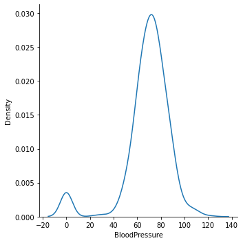

```python
sns.displot(pima['BloodPressure'], kind='kde')
plt.show()
```

**Comments:**

## The 'BMI' for the person having the highest 'Glucose'

```python
pima[pima['Glucose']==pima['Glucose'].max()]['BMI']
```

```
661    42.9
Name: BMI, dtype: float64
```

```python
pima.iloc[661,:]
```

```
Pregnancies                   1.000
Glucose                     199.000
BloodPressure                76.000
SkinThickness                43.000
Insulin                       0.000
BMI                          42.900
DiabetesPedigreeFunction      1.394
Age                          22.000
Outcome                       1.000
Name: 661, dtype: float64
```

**Comments:**

- The BMI for the person who has the highest 'Glucose' is 42.9. That person is at the row 661

## Mean, Medium, and Mode of the variable 'BMI'

```python
# Mean
m1 = pima['BMI'].mean()
print(m1)

# Median
m2 = pima['BMI'].median()
print(m2)

# Mode
m3 = pima['BMI'].mode()[0]
print(m3)
```

```
31.992578124999977
32.0
32.0
```

**Comments:**

- The mean, the median, and the mode of BMI are 31.993, 32, and 32 respectively.
- These three central tendency measures are almost the same.

## Number of women whose 'Glucose' level is above the mean level of 'Glucose'

```python
pima[pima['Glucose']>pima['Glucose'].mean()].shape[0]
```

```
349
```

**Comments:**

- There are 349 women whose Glucose level is above the mean.

## Number of women who have their 'BloodPressure' equal to the median of 'BloodPressure' and their 'BMI' less than the median of 'BMI'

```python
pima[(pima['BloodPressure']==pima['BloodPressure'].median()) & (pima['BMI']<pima['BMI'].median())].shape[0]
```

```
22
```

**Comments:**

- There are 22 wommen with BloodPressure equal to the median and BMI below the median.

## Creating the pairplot for variables 'Glucose', 'SkinThickness' and 'DiabetesPedigreeFunction'

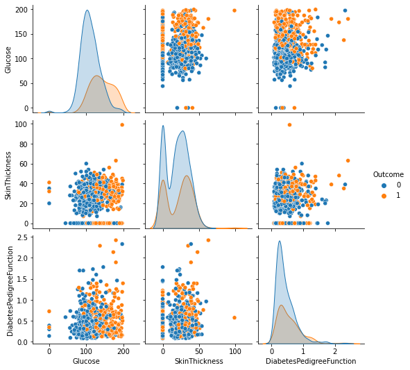

```python
sns.pairplot(data=pima,vars=['Glucose', 'SkinThickness', 'DiabetesPedigreeFunction'], hue='Outcome')
plt.show()
```

**Comments:**

- The diagonal of the pairplot is the distributions of 'Glucose', 'SkinThickness', and 'DiabetesPedigreeFunction' by the 'Outcome'.
- For each one of these three variables the distribution of disbetic people is different from the one of the non-diabetic people.
- The off-diagonal graphs are the 2-by-2 scatter plots of the three variables.

## Plotting the scatterplot between 'Glucose' and 'Insulin'

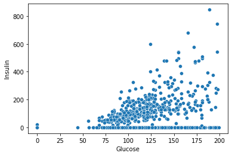

```python
sns.scatterplot(x='Glucose',y='Insulin',data=pima)
plt.show()
```

**Comments:**

- There is a positive correlation between the 'Glucose' and the 'Insulin'. However, there are many people whose Glucose level does not depend on the insulin level. Those person form a line at the bottom of the scatter plot.

## Plotting the boxplot for the 'Age' variable

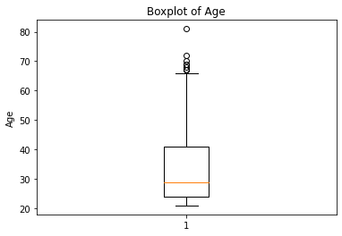

```python
plt.boxplot(pima['Age'])

plt.title('Boxplot of Age')
plt.ylabel('Age')
plt.show()
```

**Comments:**

- There are about 6 to 7 outliers in the data, all of them at the top of the box.

## Plotting histograms for variable Age to understand the number of women in different Age groups given that they have diabetes or not

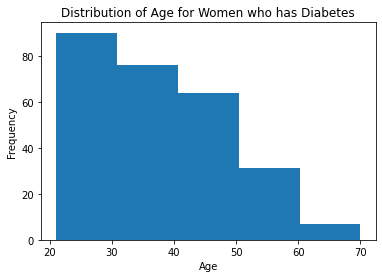

```python
plt.hist(pima[pima['Outcome']==1]['Age'], bins = 5)
plt.title('Distribution of Age for Women who has Diabetes')
plt.xlabel('Age')
plt.ylabel('Frequency')
plt.show()
```

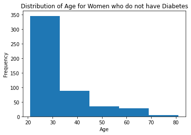

```python
plt.hist(pima[pima['Outcome']==0]['Age'], bins = 5)
plt.title('Distribution of Age for Women who do not have Diabetes')
plt.xlabel('Age')
plt.ylabel('Frequency')
plt.show()
```

**Comments:**

- The two distributions have the same tendencies.
- Both of them decreases from 20 to 80 years age.

## The inter Quartile Range of all the variables

```python
Q1 = pima.quantile(0.25)
Q3 = pima.quantile(0.75)
IQR = Q3 - Q1
print(IQR)
```

```
Pregnancies                   5.0000
Glucose                      41.2500
BloodPressure                18.0000
SkinThickness                32.0000
Insulin                     127.2500
BMI                           9.3000
DiabetesPedigreeFunction      0.3825
Age                          17.0000
Outcome                       1.0000
dtype: float64
```

**Comments:**

- The quartile range is the gap between the 25th and the 75th percentiles of a variable.
- It is used to analyze how spread 50% of the data is around the median. The boxplot visualizes the same.

## Finding and visualizing the the correlation matrix without the variable 'Outcome'

```python
corr_matrix = pima.iloc[:,0:8].corr()

corr_matrix
```

|  | Pregnancies | Glucose | BloodPressure | SkinThickness | Insulin | BMI | DiabetesPedigreeFunction | Age |
| --- | --- | --- | --- | --- | --- | --- | --- | --- |
| Pregnancies | 1.000000 | 0.129459 | 0.141282 | -0.081672 | -0.073535 | 0.017683 | -0.033523 | 0.544341 |
| Glucose | 0.129459 | 1.000000 | 0.152590 | 0.057328 | 0.331357 | 0.221071 | 0.137337 | 0.263514 |
| BloodPressure | 0.141282 | 0.152590 | 1.000000 | 0.207371 | 0.088933 | 0.281805 | 0.041265 | 0.239528 |
| SkinThickness | -0.081672 | 0.057328 | 0.207371 | 1.000000 | 0.436783 | 0.392573 | 0.183928 | -0.113970 |
| Insulin | -0.073535 | 0.331357 | 0.088933 | 0.436783 | 1.000000 | 0.197859 | 0.185071 | -0.042163 |
| BMI | 0.017683 | 0.221071 | 0.281805 | 0.392573 | 0.197859 | 1.000000 | 0.140647 | 0.036242 |
| DiabetesPedigreeFunction | -0.033523 | 0.137337 | 0.041265 | 0.183928 | 0.185071 | 0.140647 | 1.000000 | 0.033561 |
| Age | 0.544341 | 0.263514 | 0.239528 | -0.113970 | -0.042163 | 0.036242 | 0.033561 | 1.000000 |

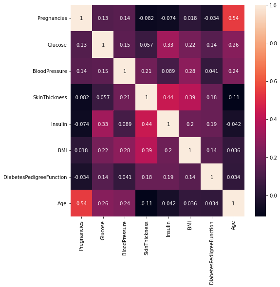

```python
plt.figure(figsize=(8,8))
sns.heatmap(corr_matrix, annot = True)
plt.show()
```

**Comments:**

# **REFERENCES**

- Great Learning Post Graduate Program: MIT Data Science and Machine Learning: Make Data Driven decisions; Practice Project: https://www.mygreatlearning.com/mit-data-science-machine-learning-program